# Assessing and Accounting for the Dependence of Age in Xe-MRI Using GAMLSS

# Account for age in Xe gas-exchange MRI analysis

Now that we understand that age is a significant variable in our distribution parameters, we can now incorporate it into the full flexible distribution model, across all subjects. We incorporate it in a very similar way to the prior section, except now we set our response variable to $\textbf{y}$, a vector of all the voxel intensities.

Before we run the model, we should account for some extra steps. First, we can apply a weighting to each of the data points, for each subject. The weighting should account for the number of data points at a given age. This is important if the number of voxels per subject changes, as you don’t want to weight your model towards a largely sampled subject. However, in our case where we only have 500 voxels per subject, this won’t actually be important.

Next, we can consider the type of link function (essentially a function that describes the modeled relationship between age and a distribution parameter) to use in our model. We chose to use a `pb-spline` link function - a penalized b-spline function that can be easily penalized to converge on smooth solutions with few degrees of freedom. One could also set the link functions to converge on linear or logarithmic models, but we reasoned that a pb-spline function would be most robust for whatever data we throw into the model.

```r
# Declare distribution family:
fit_fam = BCPE(
  mu.link = "identity",
  sigma.link = "identity",
  nu.link = "identity",
  tau.link = "identity"
)

# Declare weighting for each subject:
weighting = rep(1 / num_voxels, nrow(Voxels))

# Declare a penalty, k: current agreed value is 3.84, corresponding to chi-square test. Default is 2.
chi = 3.84

# Run GAMLSS model:
voxel_mdl <- gamlss(Intensity ~ pb(Age, method = "GAIC", k = chi),
                    # Use a pb-spline link function if age has at least a small effect size on distribution parameter.
                    if (summary(mod_gam_mu)$r.sq < 0.04) {
                      mu.formula = ~ 1} else {
                        mu.formula = ~ pb(Age, method = "GAIC", k = chi)},
                    if (summary(mod_gam_sigma)$r.sq < 0.04) {
                      sigma.formula = ~ 1} else {
                        sigma.formula = ~ pb(Age, method = "GAIC", k = chi)},
                    if (summary(mod_gam_nu)$r.sq < 0.04) {
                      nu.formula = ~ 1} else {
                        nu.formula = ~ pb(Age, method = "GAIC", k = chi)},
                    if (summary(mod_gam_tau)$r.sq < 0.04) {
                      tau.formula = ~ 1} else {
                        tau.formula = ~ pb(Age, method = "GAIC", k = chi)},
                    data = y,
                    family = fit_fam,
                    weights = weighting,
                    method = mixed(20,100)) # Convergence method for the GAMLSS model
```

## Predict the age dependent thresholds

Now that we have run the model (beware, this can take a while for large dimensions of $\textbf{y}$), we can use the model to predict the age dependent z-score bins - just like with prior linear binning and generalized linear binning methods.

|  | Age | Thresh1 | Thresh2 | Thresh3 | Thresh4 | Thresh5 |
| --- | --- | --- | --- | --- | --- | --- |
| 1 | 5.00 | 0.1275818 | 0.2250623 | 0.3275349 | 0.4453428 | 0.5987220 |
| 2 | 5.25 | 0.1281959 | 0.2260871 | 0.3290078 | 0.4473976 | 0.6017069 |
| 3 | 5.50 | 0.1288104 | 0.2271119 | 0.3304806 | 0.4494528 | 0.6046949 |
| 4 | 5.75 | 0.1294251 | 0.2281367 | 0.3319532 | 0.4515081 | 0.6076856 |
| 5 | 6.00 | 0.1300400 | 0.2291615 | 0.3334254 | 0.4535634 | 0.6106788 |
| 6 | 6.25 | 0.1306551 | 0.2301861 | 0.3348971 | 0.4556185 | 0.6136745 |
| 7 | 6.50 | 0.1312704 | 0.2312105 | 0.3363684 | 0.4576735 | 0.6166725 |
| 8 | 6.75 | 0.1318858 | 0.2322347 | 0.3378392 | 0.4597282 | 0.6196729 |
| 9 | 7.00 | 0.1325013 | 0.2332586 | 0.3393094 | 0.4617826 | 0.6226754 |
| 10 | 7.25 | 0.1331169 | 0.2342823 | 0.3407790 | 0.4638366 | 0.6256800 |

## Interpretation

# Summary

In this markdown document, we have shown the basic elements of implementing GAMLSS into Xe gas-exchange MRI analysis. The code from this notebook can be copied and implemented into your own studies, all using open-source software in R-studio. It is possible to make an R executable for MATLAB or Python, so your analysis package can be easily implemented to your current studies.

Of course, we have only shown the most basic elements of GAMLSS functionality. One of the most exciting features is that you can add more explanatory variables, such as sex. This is possible by simply changing your model arguments to `Intensity ~ pb(Age + Sex, method = "GAIC", k = chi)`, and then ensuring your data is set up with the right type of variable (`factor` for sex), and ensuring you have an adequate amount of data to avoid over-fitting.

# Appendix

You can also implement current thresholding methods, like linear binning and generalized linear binning. This is achieved as below:

## Generalized linear binning thresholds

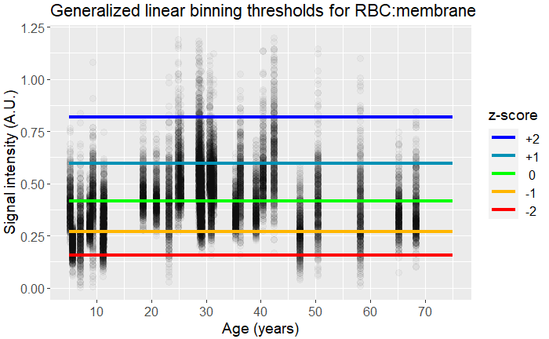

```r
# Declare distribution family:
fit_fam = BCCG(
  mu.link = "identity",
  sigma.link = "identity",
  nu.link = "identity"
)

# Declare weighting for each subject:
weighting = rep(1 / num_voxels, nrow(Voxels))

# Declare a penalty, k: current agreed value is 3.84, corresponding to chi-square test. Default is 2.
chi = 3.84

# Run GAMLSS model:
voxel_mdl <- gamlss(Intensity ~ 1,
                    sigma.formula = ~ 1,
                    data = y,
                    family = fit_fam)
# Simulate an age range:
sim_age <- data.frame(Age = seq(5, 75, 0.25))

# Use the centiles.pred function to predict percentiles (can be correlated to a distribution z-score).
thresholds <- centiles.pred(
  voxel_mdl,
  xname = "Age",
  xvalues = sim_age$Age,
  cent = c(2.275013, 15.865525, 50, 84.134475, 97.724987)
)

# Store the predictions:
Pred <- data.frame(Age = sim_age$Age)
Pred$Age <- sim_age$Age
Pred$Thresh1 <- thresholds$`2.275013`
Pred$Thresh2 <- thresholds$`15.865525`
Pred$Thresh3 <- thresholds$`50`
Pred$Thresh4 <- thresholds$`84.134475`
Pred$Thresh5 <- thresholds$`97.724987`

# Plot the thresholds:
ggplot(data = y,
       aes(x = Age, y = Intensity)) +
  geom_point(alpha = 0.03,
             size = 3,
             color = "black") +
  geom_path(data = Pred,
            aes(x = Age, y = Thresh1, color = "1"),
            size = 1.5) +
  geom_path(data = Pred,
            aes(x = Age, y = Thresh2, color = "2"),
            size = 1.5) +
  geom_path(data = Pred,
            aes(x = Age, y = Thresh3, color = "3"),
            size = 1.5) +
  geom_path(data = Pred,
            aes(x = Age, y = Thresh4, color = "4"),
            size = 1.5) +
  geom_path(data = Pred,
            aes(x = Age, y = Thresh5, color = "5"),
            size = 1.5) +
  scale_colour_manual(values = c(rgb(1,0,0),
                                 rgb(1, 0.7143, 0),
                                 rgb(0, 1, 0),
                                 rgb(0, 0.57, 0.71),
                                 rgb(0, 0, 1)),
                      labels = c("-2",
                                 "-1",
                                 " 0",
                                 "+1",
                                 "+2")) +
  guides(color = guide_legend(reverse = TRUE)) +
  scale_x_continuous(limits = c(min(sim_age), max(sim_age)),
                     breaks = seq(10, 70,10)) +
  theme(legend.text = element_text(size = 12),
        legend.key.width = unit(1, 'cm'),
        title = element_text(size = 14),
        axis.text = element_text(size = 12),
        plot.margin = unit(c(1, 1, 1, 1), "mm")) +
  labs(x = "Age (years)",
       y = "Signal intensity (A.U.)",
       color = "z-score") +
  ylim(c(0, 1.2)) +
  ggtitle("Generalized linear binning thresholds for RBC:membrane")
```